# MEDL_PS02_Soln

**Deep Learning for Mechanical Engineering**  
**Homework 02 - Solution**

Instructor: Prof. Seungchul Lee  
http://iailab.kaist.ac.kr/  
Industrial AI Lab at KAIST

- For your handwritten solution, scan or take a picture of them (you can write it in markdown if you want).
- For your code, only .ipynb file will be graded.
  - Please write your NAME and student ID on your .ipynb files. ex) IljeokKim_20202467_HW02.ipynb
- Please compress all the files to make a single .zip file
  - Please write your NAME and student ID on your .zip files. ex) DogyeomPark_20202467_HW02.zip
  - Submit it to KLMS
- Do not submit a printed version of your code. It will not be graded.

# Problem 1: Linear System with TensorFlow

You will solve the following system of linear equations using TensorFlow:

$$ \begin{align*} x + 2y - 3z = 4\\ x - y - z = 0\\ 2x + y - 2z = 6 \end{align*} $$

(a) Use `tf.constant` to find $u = (x, y, z)^T$.

$$u = A^{-1}b$$

```python
import numpy as np
import tensorflow as tf

A = tf.constant([1, 2, -3, 1, -1, -1, 2, 1, -2], dtype = tf.float32)
b = tf.constant([4, 0, 6], dtype = tf.float32)

A = tf.reshape(A, [3, 3])
b = tf.reshape(b, [3, 1])
```

```python
# Your code here

A_inv = tf.linalg.inv(A)
u = tf.matmul(A_inv, b)

print('u:\n', u)
```

```
u:
 tf.Tensor(
[[3.]
 [2.]
 [1.]], shape=(3, 1), dtype=float32)
```

(b) You can design an objective function and optimize it to find $u$ although it has an exact solution.

$$\min_{u} \; \rVert Au - b\lVert^2$$

- Use `tf.Variable`.
- You can use: `tf.reduce_mean`, `tf.math.square`, `tf.keras.optimizers.SGD()`

```python
# Your code here

u = tf.Variable([[0], [0], [0]], dtype = tf.float32)

optm = tf.keras.optimizers.SGD(learning_rate = 0.1)

for _ in range(500):
    with tf.GradientTape() as tape:
        loss = tf.reduce_mean(tf.math.square(tf.matmul(A, u) - b))
        u_grad = tape.gradient(loss, [u])

    optm.apply_gradients(zip(u_grad, [u]))

print('u:\n', u.numpy())
```

```
u:
 [[2.9999988 ]
 [1.9999994 ]
 [0.99999905]]
```

# Problem 2: Digit Classification with Scikit-Learn

In this problem, we will try to classify handwritten digits. For the sake of simplicity, we simplify this digit classification problem into a binary classification between digit 0 and digit 1.

## Step 1. Load the Data

| Data | Data description |
| --- | --- |
| 0 | 1000 images (28×28 pixels) of handwritten digit 0 |
| 1 | 1000 images (28×28 pixels) of handwritten digit 1 |

- [Download data](https://www.dropbox.com/s/5tsu4kfitgbqk11/data.pkl?dl=1) to read the files in Python.

To read the files in Python, use the following code:

```python
import numpy as np
import matplotlib.pyplot as plt
from six.moves import cPickle

data = cPickle.load(open('./data_files/data.pkl', 'rb'))
data0 = data['0']
data1 = data['1']

print('digit 0: ', data0.shape)
print('digit 1: ', data1.shape)
```

```
digit 0:  (1000, 28, 28)
digit 1:  (1000, 28, 28)
```

Here, we loaded 2000 numbers of data from ‘0’ and ‘1’. To display the image, use `plt.imshow(img)`.

(1) Display a few random images in each class.

- Note: make sure you are reading the files correctly. Check by displaying a few random images in each class.

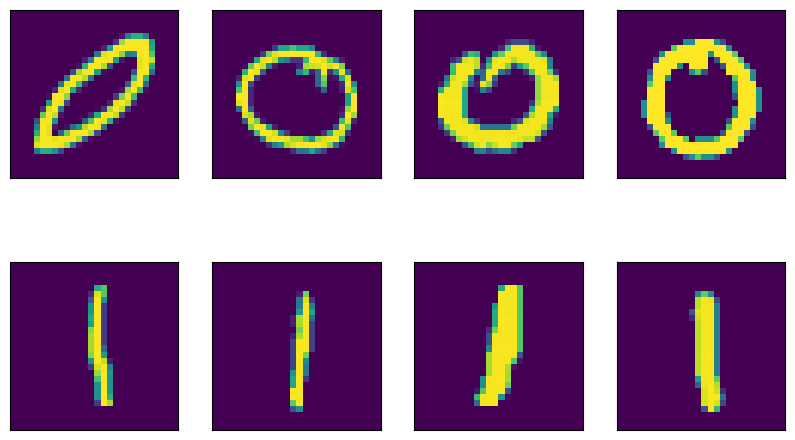

```python
# Your code here

plt.figure(figsize = (10,6))

for i in range(1,5):
    plt.subplot(2,4,i)
    plt.imshow(data0[np.random.randint(len(data0))].reshape(28,28))
    plt.xticks([]); plt.yticks([])

    plt.subplot(2,4,4+i)
    plt.imshow(data1[np.random.randint(len(data1))].reshape(28,28))
    plt.xticks([]); plt.yticks([])

plt.show()
```

(2) Convert each of the pixels in 28×28 matrix to a binary value.

- Note: calculations are more manageable if you go though and convert each of the pixels in $28\times28$ matrix to a binary value first.

```python
# Convert each of the pixels in 28×28 matrix to a binary value
# Your code here

data0 = data0 > 128
data1 = data1 > 128
```

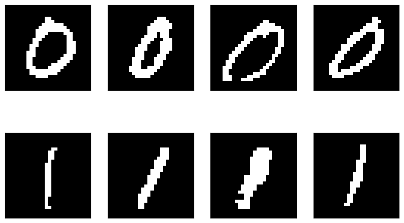

```python
plt.figure(figsize = (10,6))

for i in range(1,5):
    plt.subplot(2,4,i)
    plt.imshow(data0[np.random.randint(len(data0))].reshape(28,28), 'gray')
    plt.xticks([]); plt.yticks([])
    plt.subplot(2,4,4+i)
    plt.imshow(data1[np.random.randint(len(data1))].reshape(28,28), 'gray')
    plt.xticks([]); plt.yticks([])

plt.show()
```

## Step 2. Extract Features

Now we must select ‘features’ from image data to detect digit 0 and digit 1. Two features are recommended

$\;\;$ (a) The total average pixels located at the center of the image (`img[10:20,10:20]`).

$\;\;$ (b) The total average pixels over the entire image.

$$\Phi(x) = \begin{bmatrix} \text{feature1}\\ \text{feature2} \end{bmatrix}^T$$

You should end up with a $2000 \times 2$ input matrix with the first $1000$ rows correspond to all of the ‘`data0`’ and the second 1000 rows correspond to the two features for all of the given ‘`data1`’.

```python
# Your code here

# Average pixels locaed at the center of the image
feature0_1 = np.sum(data0[:,10:20,10:20], axis = (1,2)).reshape(-1,1)/100
feature1_1 = np.sum(data1[:,10:20,10:20], axis = (1,2)).reshape(-1,1)/100

# Total average pixels over the entire location
feature0_2 = np.sum(data0, axis = (1,2)).reshape(-1,1)/(28*28)
feature1_2 = np.sum(data1, axis = (1,2)).reshape(-1,1)/(28*28)

A0 = np.hstack([feature0_1, feature0_2])
A1 = np.hstack([feature1_1, feature1_2])
A = np.vstack([A0, A1])

print(A.shape)
```

```
(2000, 2)
```

## Step 3. Plot the Data

Plot the data to see if classes are separable. The expected plot is the following:

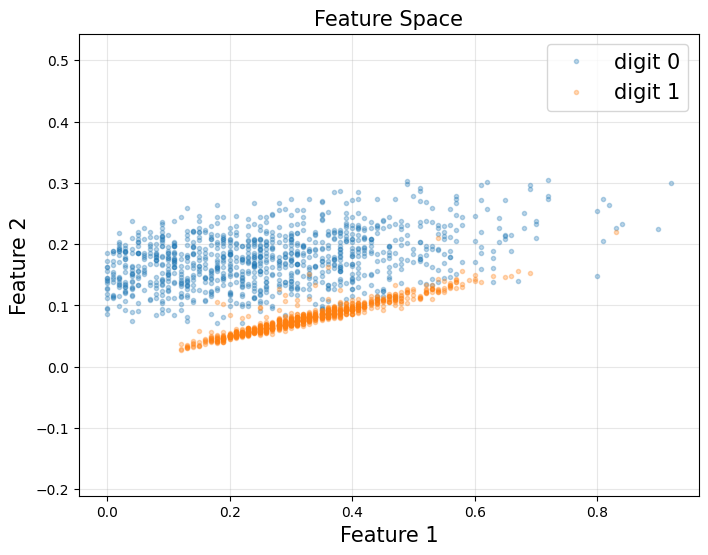

```python
# Your code here

plt.figure(figsize = (8, 6))

plt.plot(feature0_1, feature0_2, '.', alpha = 0.3, label = 'digit 0')
plt.plot(feature1_1, feature1_2, '.', alpha = 0.3, label = 'digit 1')

plt.axis('equal')
plt.grid(alpha = 0.3)
plt.legend(fontsize = 15)
plt.xlabel('Feature 1', fontsize = 15)
plt.ylabel('Feature 2', fontsize = 15)
plt.title('Feature Space', fontsize = 15)
plt.show()
```

## Step 4. Digit Classification with Logistic Regrssion

(1) Use the logistic regression algorithm to classify digit0 and digit1 data set.

- Note: you don't need to implement full algorithm by yourself. Just use sklearn library which we have learned in class.
- Use `LogisticRegression()

```python
# Your code here

from sklearn import linear_model

y = np.vstack([np.zeros([len(data0), 1]), np.ones([len(data1), 1])])

clf = linear_model.LogisticRegression()
clf.fit(A, np.ravel(y))
```

```
LogisticRegression()
```

(2) Plot the classifier (decision boundary).

$\;\;\;$ Note that the decision boundary is given:

$$\omega_1 x_1 + \omega_2x_2 + \omega_0 = 0$$

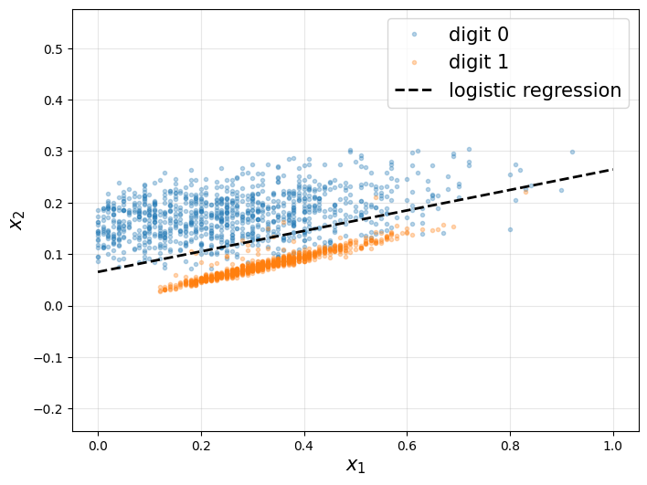

```python
# Your code here

w0 = clf.intercept_[0]
w1 = clf.coef_[0,0]
w2 = clf.coef_[0,1]

x1p = np.linspace(0,1).reshape(-1,1)
x2p = - w1/w2*x1p - w0/w2

plt.figure(figsize = (8, 6))
plt.plot(feature0_1, feature0_2, '.', alpha = 0.3, label = 'digit 0')
plt.plot(feature1_1, feature1_2, '.', alpha = 0.3, label = 'digit 1')
plt.plot(x1p, x2p, 'k--', linewidth = 2, label = 'logistic regression')
plt.axis('equal')
plt.grid(alpha = 0.3)
plt.xlabel('$x_1$', fontsize = 15)
plt.ylabel('$x_2$', fontsize = 15)
plt.legend(loc = 1, fontsize = 15)
plt.show()
```

# Problem 3: Understanding Probability in Logistic Regression

In this problem, we are going to understand probability in the logistic regression.

Note: you need to write down full codes for this problem by yourself. Do not just use sklearn library.

**Linear Regression vs. Logistic Regression**

In the case of categorical (0 or 1) data, linear regression is not possible to properly represent the relationship between input and output data. As shown in the figure on the right, logistic regression adds a non-linear characteristic (sigmoid function) to linear regression and fits the relationship between input and output data into a curve.

We can define the S-Curve as a probability by the characteristics of the sigmoid function.

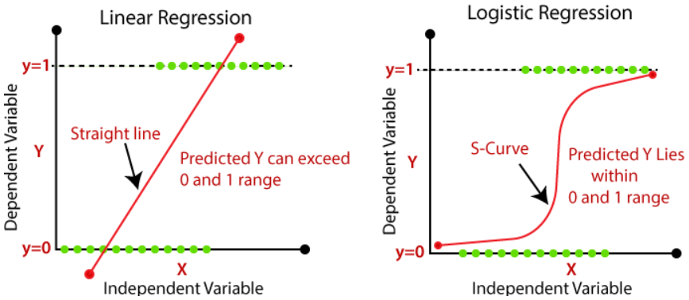

## Step 1. Data Generation

We are going to examine the relationship between basketball shooting accuracy and the number of shot. More specifically, We want a model that takes in "the number of shot" and spits out the probability that you will make the shot.

Here is the shape of $\omega$ and $x$.

$$ \begin{align*} \omega &= \begin{bmatrix} \omega_0 \\ \omega_1 \end{bmatrix}, \qquad x = \begin{bmatrix} 1 \\ x_1 \end{bmatrix}\\ \\ X &= \begin{bmatrix} \left(x^{(1)}\right)^T \\ \left(x^{(2)}\right)^T \\ \left(x^{(3)}\right)^T \\ \vdots\end{bmatrix} = \begin{bmatrix} 1 & x_1^{(1)} \\ 1 & x_1^{(2)} \\ 1 & x_1^{(3)} \\ \vdots & \vdots \\\end{bmatrix}, \qquad y = \begin{bmatrix} y^{(1)}\\ y^{(2)} \\y^{(3)} \\ \vdots \end{bmatrix} \end{align*} $$

(1) Generate the data set by the following description.

| Data description |  |  |  |  |  |  |  |  |  |  |  |  |  |  |  |  |  |  |  |  |  |  |  |  |  |  |  |  |  | … |
| --- | --- | --- | --- | --- | --- | --- | --- | --- | --- | --- | --- | --- | --- | --- | --- | --- | --- | --- | --- | --- | --- | --- | --- | --- | --- | --- | --- | --- | --- | --- |
| Number of Shot (X) | 1 | 2 | 3 | 4 | 5 | 6 | 7 | 8 | 9 | 10 | 11 | 12 | 13 | 14 | 15 | 16 | 17 | 18 | 19 | 20 | 21 | 22 | 23 | 24 | 25 | 26 | 27 | 28 | 29 | … |
| Made (Y) | 0 | 0 | 0 | 0 | 0 | 0 | 1 | 0 | 1 | 0 | 0 | 1 | 1 | 0 | 0 | 1 | 1 | 1 | 0 | 1 | 1 | 1 | 1 | 1 | 0 | 1 | 1 | 1 | 1 | … |

(2) After generating all data, plot them to check it.

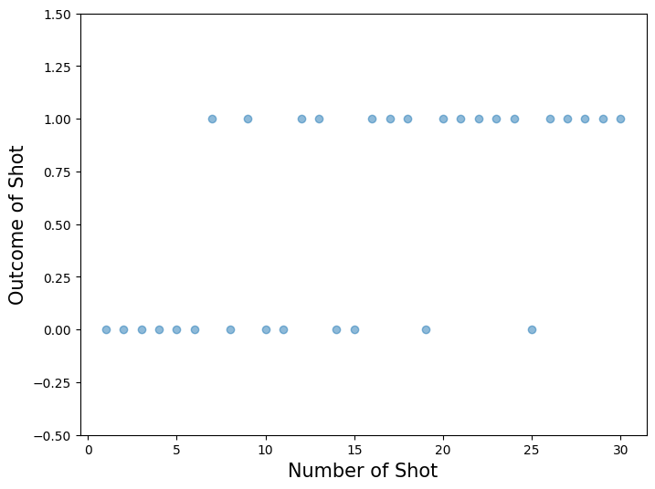

```python
# Your code here

import numpy as np
import matplotlib.pyplot as plt

made = [0, 0, 0, 0, 0, 0, 1, 0, 1, 0, 0, 1, 1, 0, 0, 1, 1, 1, 0, 1, 1, 1, 1, 1, 0, 1, 1, 1, 1, 1]
num = [i for i in range(1, 31)]

X = np.hstack([np.ones([len(made), 1]), np.array(num).reshape(-1, 1)])
y = np.array(made).reshape(-1, 1)

X = np.asmatrix(X)

plt.figure(figsize = (8, 6))
plt.plot(num, made, '.', alpha = 0.5, markersize = 12)
plt.ylim([-0.5, 1.5])
plt.xlabel('Number of Shot', fontsize = 15)
plt.ylabel('Outcome of Shot', fontsize = 15)
plt.show()
```

## Step 2. Logistic Regression with Gradient Descent

(1) Define the sigmoid (logistic) function.

$$h_{\omega}(x) = h(x\,;\omega) = \sigma \left(\omega^T x\right) = \frac{1}{1+e^{-\omega^T x}}$$

```python
# Your code here

def h(x,w):
    return 1/(1 + np.exp(-x*w))
```

(2) [hand written] Write the gradient of log likelihood.

**Solution**

The likelihood function is

$$ \begin{align*} L(\omega) &= \prod\limits_{i=1}^{m}P(y^{(i)}|x^{(i)};\omega)= \prod\limits_{i=1}^{m}(h_\omega (x^{(i)})^{y^{(i)}})(1-h_\omega (x^{(i)}))^{(1-y^{(i)})}\\\\ \ell(\omega) &= \frac{1}{m} \log L(\omega) = \frac{1}{m}\sum\limits_{i=1}^m y^{(i)} \{\log(h_\omega (x^{(i)})) + (1-y^{(i)}) \log(1-h_\omega(x^{(i)}))\}\\\\ \nabla \ell(\omega) &= \frac{1}{m} \sum\limits_{i=1}^{m} \left\{\frac{y^{(i)}}{h_\omega (x^{(i)})} \frac{\partial h_\omega}{\partial \omega} -\frac{1-y^{(i)}}{1-h_\omega (x^{(i)})} \frac{\partial h_\omega}{\partial \omega}\right\}\\\\ \frac{\partial h_\omega}{\partial \omega} &= \frac{\partial \sigma(z^{(i)})}{\partial z^{(i)}} \frac{\partial z^{(i)}}{\partial \omega}= \frac{\partial \sigma(z^{(i)})}{\partial z^{(i)}}x^{(i)} \\\\ \nabla \ell(\omega) &= \frac{1}{m} \sum\limits_{i=1}^{m} (y^{(i)}-h_\omega (x^{(i)}))x^{(i)} \end{align*} $$

Thus,

$$\nabla \ell(\omega) = \begin{bmatrix} \frac{\partial \ell(\omega)}{\partial \omega_0} \\ \frac{\partial \ell(\omega)}{\partial \omega_1} \\ \frac{\partial \ell(\omega)}{\partial \omega_2} \end{bmatrix} = X^T \left(y-h_{\omega}(x)\right) = X^T \left(y-\sigma(X \omega)\right) $$

(3) [hand written] Write the gradient descent algorithm for this problem.

Note: this problem is a maximization problem.

**Solution**  
This problem is a maximization problem, so we need to make it minimization problem to use gradient descent method.

Since $\min\{\nabla \ell(\omega)\} = \max\{-\nabla \ell(\omega)\}$, we can convert this problem to minimization problem by simply change the sign of gradient.

$$\omega \leftarrow \omega - \eta \left( - \nabla \ell(\omega)\right)$$

(4) Initialize $\omega$ and update it by the gradient descent method.

```python
# Your code here

w = np.zeros([2,1])
alpha = 0.001

for i in range(10000):
    df = -X.T*(y - h(X,w))
    w = w - alpha*df

print(w)
```

```
[[-2.58701913]
 [ 0.19500517]]
```

## Step 3. Linear Regression with Gradient Descent

(1) [hand writtern] The below is the objective function of linear regression.

$$ \min_{\theta} ~ \lVert \hat y - y \rVert_2^2 = \min\limits_\theta {\lVert X\theta - y \rVert}_2^2$$

Write the gradient of least squares solution.

**Solution**

let $J(x) = \lVert X\theta-y\rVert^2_{2}$

$$ \begin{align*} J(x) &= (X\theta-y)^T(X\theta-y)\\\\ &= (\theta^TX^T-y^T)(X\theta-y)\\\\ &= \theta^TX^TX\theta - \theta^TX^Ty - y^TX\theta+y^Ty\\\\ \end{align*} $$

Thus,

$$ \begin{align*} \frac{\partial{J}}{\partial{\theta}} &= X^TX\theta+(X^TX)^T\theta - X^Ty - {(y^TX)}^T\\\\ &= 2(X^TX\theta - X^Ty) \end{align*} $$

(2) Initialize $\theta$ and update it by the gradient descent method.

Note: this problem is a minimization problem.

```python
# Your code here

theta = np.ones([2,1])
alpha = 0.0001

for i in range(10000):
    df = 2*(X.T*X*theta - X.T*y)
    theta = theta - alpha*df

print(theta)
```

```
[[0.02528796]
 [0.03492767]]
```

## Step 4. Compare Linear Regression and Logistic Regression Models

(1) Define the prediction model and make predictions using the trained models

- Linear regression: $y = \theta_0 + \theta_1 X$
- Logistic regression: $y = \sigma(\omega_0 + \omega_1 X)$

```python
# Your code here
def get_predictions(w, theta):
    logistic_predictions = h(X,w)
    linear_predictions = X*theta

    return np.array(logistic_predictions), np.array(linear_predictions)

logistic_pred, linear_pred = get_predictions(w, theta)
```

(2) Plot the predicted values.

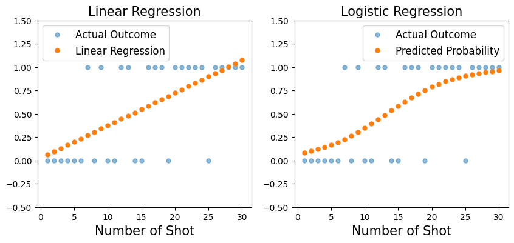

```python
# Your code here

plt.figure(figsize = (10, 4))

plt.subplot(1,2,1)
plt.plot(num, made, '.', alpha = 0.5, markersize = 10, label = 'Actual Outcome')
plt.plot(num, linear_pred, '.', markersize = 10, label = 'Linear Regression')
plt.ylim([-0.5, 1.5])
plt.xlabel('Number of Shot', fontsize = 15)
plt.title('Linear Regression', fontsize = 15)
plt.legend(fontsize = 12)

plt.subplot(1,2,2)
plt.plot(num, made, '.', alpha = 0.5, markersize = 10, label = 'Actual Outcome')
plt.plot(num, logistic_pred, '.', markersize = 10, label = 'Predicted Probability')
plt.ylim([-0.5, 1.5])
plt.xlabel('Number of Shot', fontsize = 15)
plt.legend(fontsize = 12)
plt.title('Logistic Regression', fontsize = 15)
plt.show()
```

## Step 5. Cost Function of Logistic Regression

The cost function summarizes how well the model is behaving. In other words, we use the cost function to measure how close the model’s predictions are to the actual outputs.

**Log likelihood**

$$\ell(\omega) = \frac{1}{m} \log L(\omega) = \frac{1}{m}\sum\limits_{i=1}^m y^{(i)} \{\log(h_\omega (x^{(i)})) + (1-y^{(i)}) \log(1-h_\omega(x^{(i)}))\} $$

Thus, we can define the cost for two cases separately:

$$ \text{cost}(h_{\theta}(x),y) = \begin{cases} -\log (h_{\theta}(x)) \quad &\text{if } y = 1\\ -\log (1-h_{\theta}(x)) \quad &\text{if } y = 0 \end{cases} $$

Which then results in:

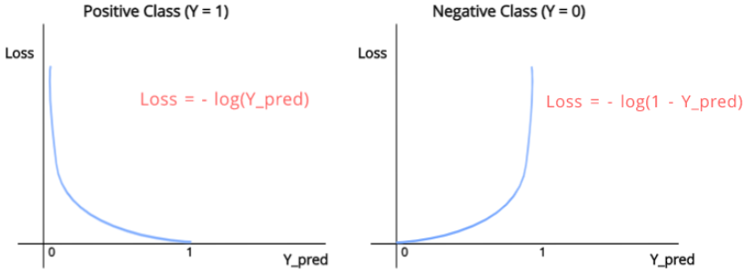

Plot the cost function using the predicted values from logistic regression.

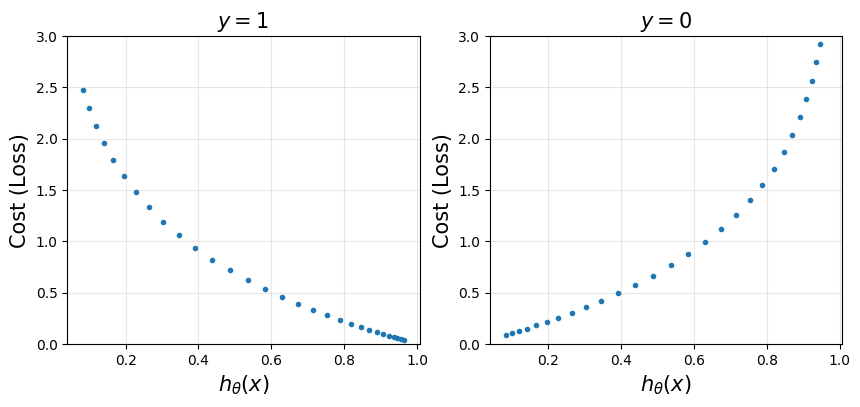

```python
# Your code here

sigmoid_x = h(X,w)

cost_1 = -np.log(logistic_pred)
cost_0 = -np.log(1 - logistic_pred)

plt.figure(figsize = (10, 4))

plt.subplot(1,2,1)
plt.plot(sigmoid_x, cost_1, '.')
plt.ylim([0, 3])
plt.grid(alpha = 0.3)
plt.ylabel('Cost (Loss)', fontsize = 15)
plt.xlabel('$h_{\\theta}(x)$', fontsize = 15)
plt.title('$y = 1$', fontsize = 15)

plt.subplot(1,2,2)
plt.plot(sigmoid_x, cost_0, '.')
plt.ylim([0, 3])
plt.grid(alpha = 0.3)
plt.ylabel('Cost (Loss)', fontsize = 15)
plt.xlabel('$h_{\\theta}(x)$', fontsize = 15)
plt.title('$y = 0$', fontsize = 15)
plt.show()
```